# Covid19 Vaccinations 12-29-2020

CodeByDom

12/29/2020

## Total Vaccine Distribution Total for the World

To track the vaccination efforts, I scrapped vaccination data from the web using publicly available data sources.

Data from: Our World in Data, https://ourworldindata.org/.

Location and Date (YYYY-MM-DD) data was last updated:

```
# A tibble: 25 x 2
# Groups:   location [25]
   location   date
   <chr>      <chr>
 1 Bahrain    2020-12-28
 2 Bulgaria   2020-12-29
 3 Canada     2020-12-28
 4 Chile      2020-12-27
 5 China      2020-12-19
 6 Costa Rica 2020-12-24
 7 Denmark    2020-12-28
 8 England    2020-12-20
 9 Estonia    2020-12-29
10 Germany    2020-12-28
# ... with 15 more rows
```

#### Figure 1: Global Covid 19 Vaccination Total by Location

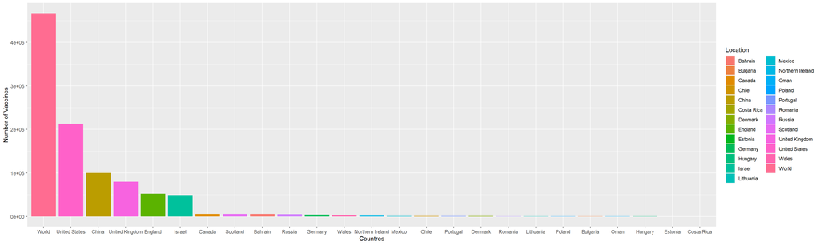

However, this graph is slightly misleading because it does not put into account the total populations of the Locations being observed, when it comes to the total vaccinations per 100 people the graph looks like this.

#### Figure 2: Global Covid 19 Vaccination total per 100 people by Location

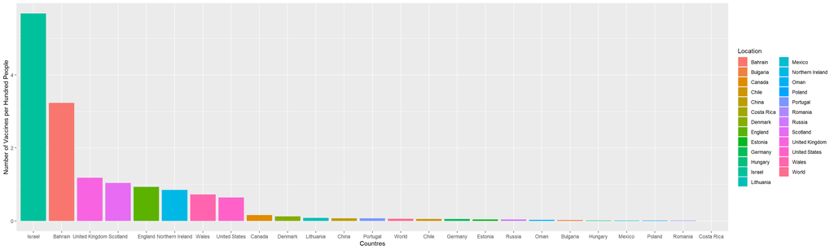

## Total Vaccine (Pfizer) Distribution Total for the United States

Data from CDC: Center of Disease Control and Prevention, https://data.cdc.gov/Vaccinations/COVID-19-Vaccine-Initial-Allocations-Pfizer/saz5-9hgg/data.

#### Figrue 3: Top 10 as Percentage of the Population (2015) Vaccinated with Covid-19 Vaccine (Pfizer)

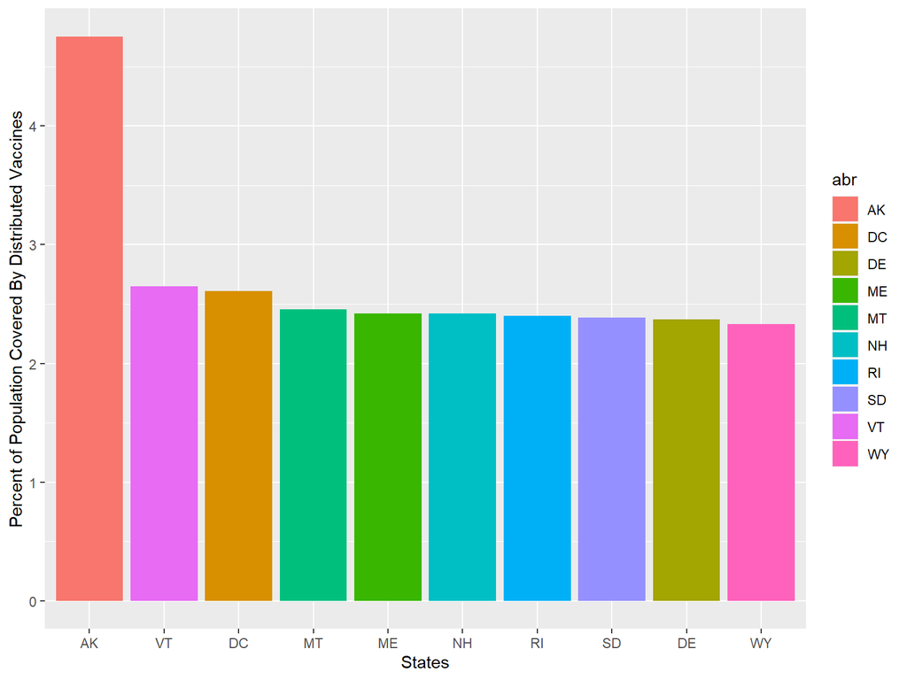

#### Figrue 4: Top 10 as Total Vaccinated with Covid-19 Vaccine (Pfizer)

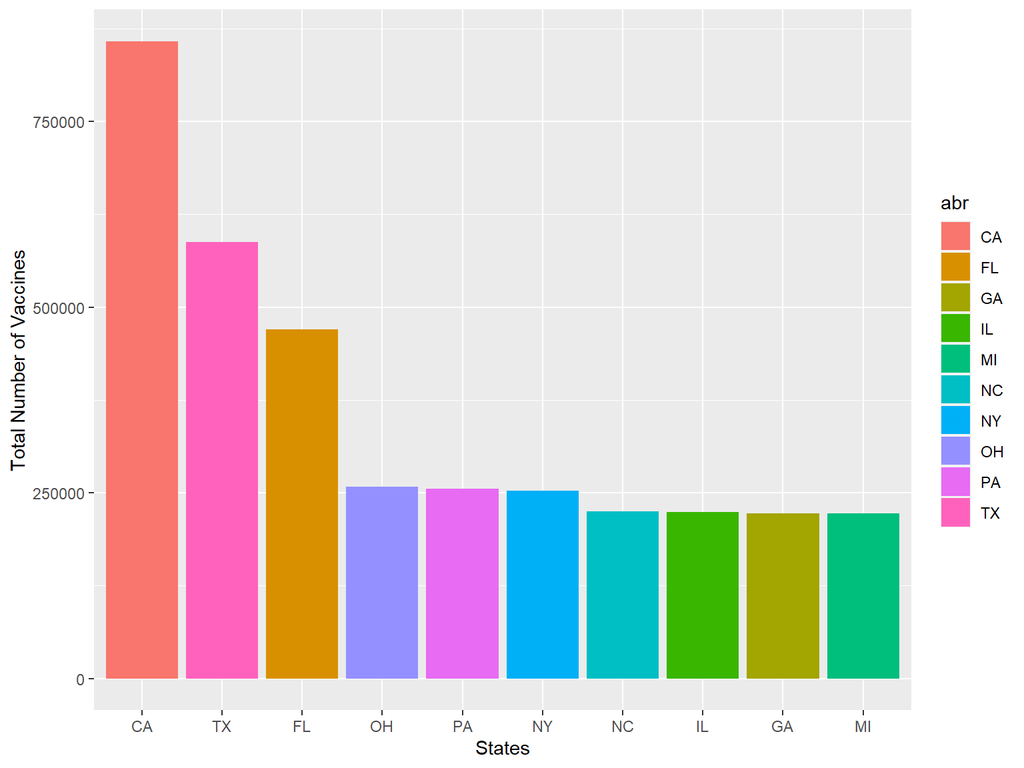

#### Figure 5: United States Density Map of Coverage Percentage of Population (2015) for Vaccines Distributed (Pfizer)

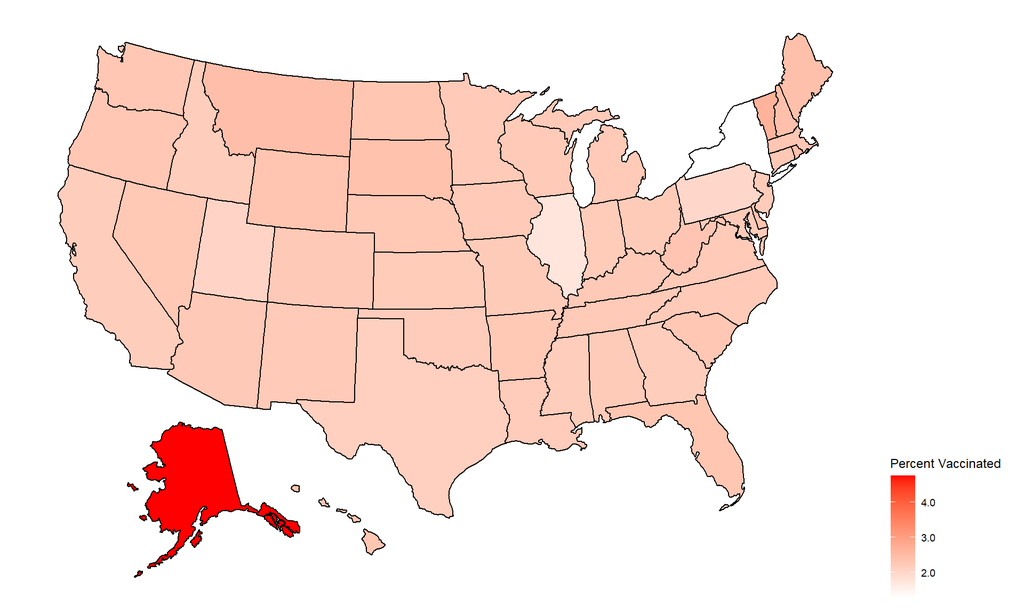

#### Figure 6: United States Density Map of Total Vaccinations Distributed (Pfizer)

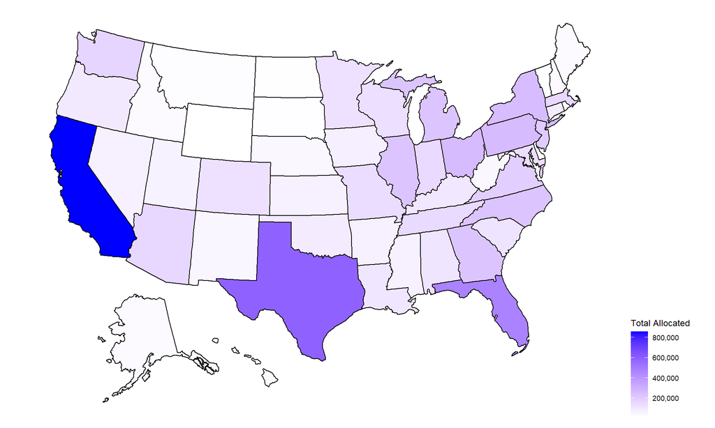

## Total Vaccine (Moderna) Distribution Total for the United States

[figure not shown]

#### Figure 8: Top Ten States with Allocated Vaccines (Moderna)

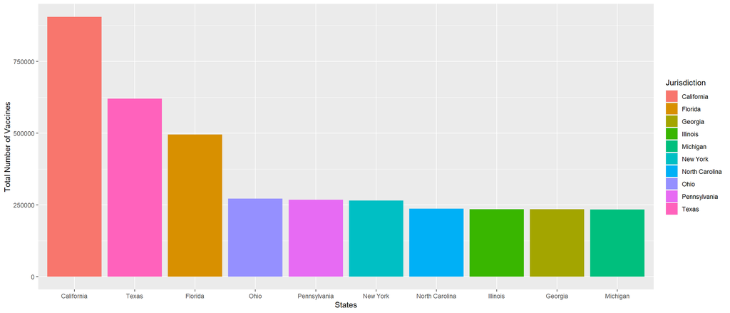

#### Figure 9: Density map of the Percent Covered with Moderna Vaccinations

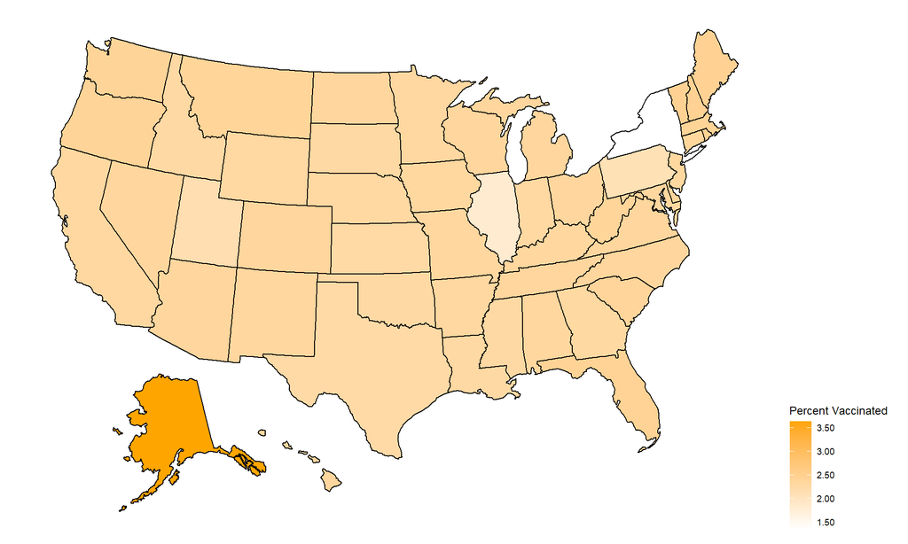

#### Figure 10: Density map of the Total Vaccines (Moderna) Allocated

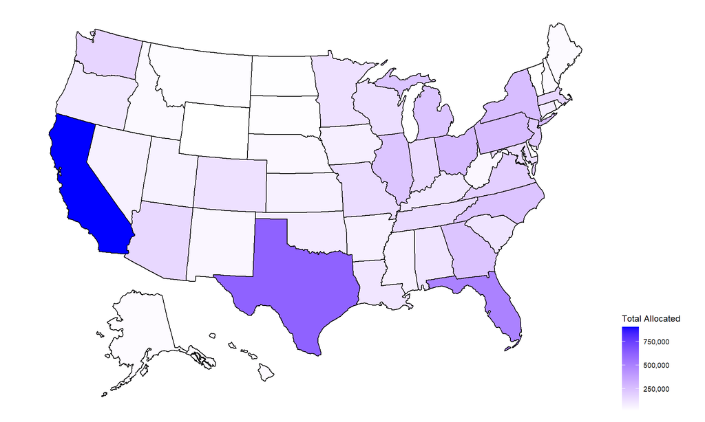

## Total Vaccine (Pfizer + Moderna) Distribution Total for the United States

#### Figure 11: Top Ten States with Allocated Vaccines as Percentage of Population (Pfizer + Moderna)

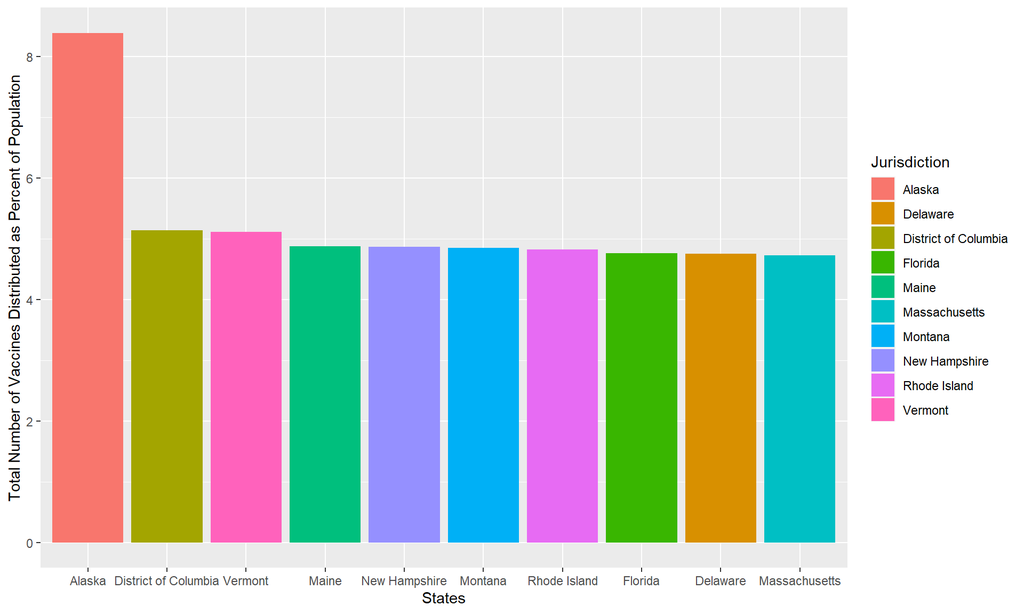

#### Figure 12: Top Ten States for Total Allocated Vaccines (Pfizer + Moderna)

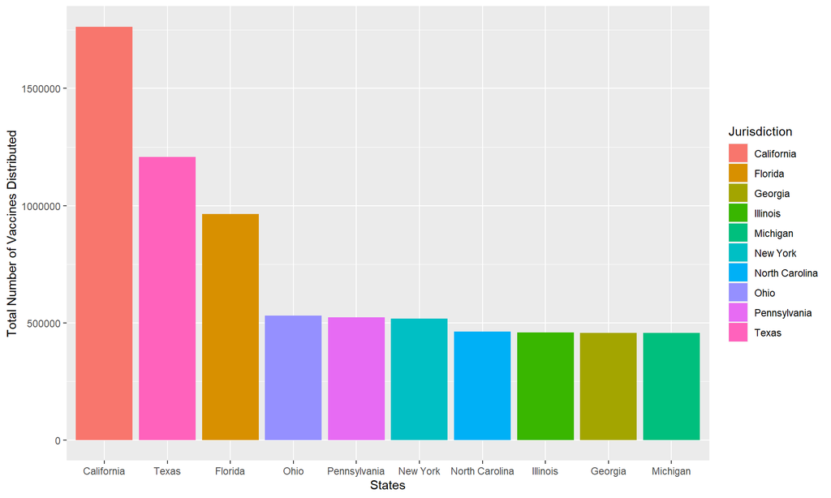

#### Figrue 13: Total Vaccines (Pfizer + Moderna) Allocated Density Map

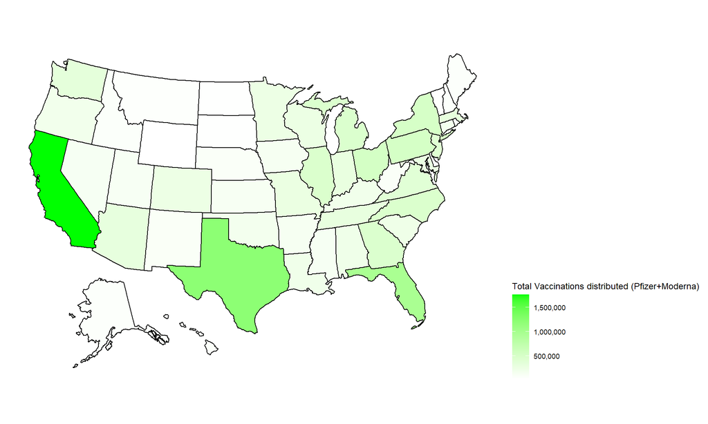

#### Firgure 14: Total Vaccines (Pfizer + Moderna) Allocated as Percentage of the Population

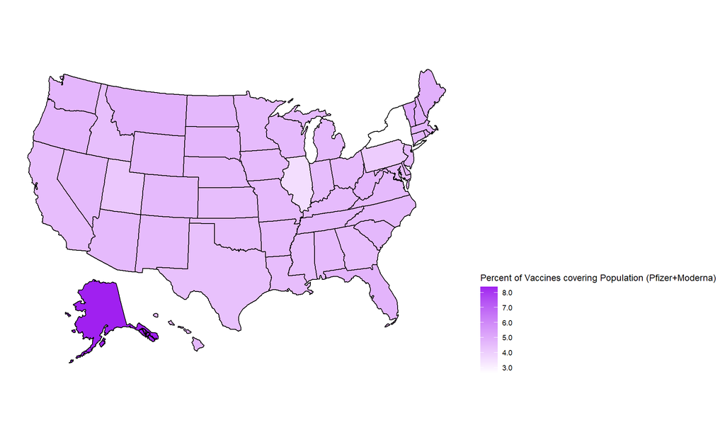

This report is meant to give insight into which states and countries can allocate vaccines to the most people during the initial days of availability for vaccines. Since the data comes from websites with data sources that are being continously updated, next time re-running this R report, there will be new figures and updated data.